# 10. Oak ambrosia beetle (*Platypus quercivorus*)

Published

October 29, 2026

Download OAB report as PDF

## **10A. Introduction**

The oak ambrosia beetle (OAB), *Platypus quercivorus* Murayama (Coleoptera: Platypodidae), is a destructive forest pest distributed across India, Indonesia, Japan, and Papua New Guinea (Davis et al. 2005; USDA-APHIS 2011; EPPO 2020). The beetle vectors its symbiotic fungal pathogen, *Raffaelea quercivora* Kubono & Shin-Ito, which causes Japanese oak wilt disease (JOW) by disrupting tracheary function and can kill both healthy and stressed trees (Kubono and Ito 2002; Kamata et al. 2002; Davis et al. 2005; Kobayashi and Ueda 2005). Suitable host plants for reproduction include species of *Quercus* as well as other members of the Fagaceae, including chestnut (*Castanea* spp.), chinquapin (*Castanopsis* spp.), and stone oaks (*Lithocarpus* spp.), although OAB may also attack non-host tree species near areas experiencing mass infestation (Davis et al. 2005). The beetle–fungus complex has caused extensive oak mortality in Japan, where OAB preferentially attacks larger trees with higher water content, making abandoned oak coppice forests particularly vulnerable to infestation (Kobayashi and Ueda 2005; Nakajima 2019; EPPO 2020). If introduced to the United States, OAB and JOW could pose substantial economic, environmental, and social risks because of the potential for mortality of susceptible oak and other *Fagaceae* species. Although *R. quercivora* has only been reported from Japan, the distribution of OAB across multiple countries in Asia and Oceania highlights the potential for movement of the beetle through international trade and other pathways (Davis et al. 2005; USDA-APHIS 2011; EPPO 2020).

Several studies have predicted suitable conditions for OAB across much of the United States, although the predicted range varies among studies (USDA-APHIS 2011; Barker and Coop 2020; Takeuchi et al. 2023). Suitable conditions have been predicted across most of the country, including much of the Pacific Coast, Puerto Rico, and Hawaii, with the northern Midwest generally representing areas of lower suitability (USDA-APHIS 2011; Barker and Coop 2020; Takeuchi et al. 2023). Areas with abundant oak resources would therefore be expected to face the greatest risk of establishment and impact. OAB could potentially complete one to three generations annually in the United States, compared with generally one generation per year in Japan, although a second generation may occasionally occur (Kamata et al. 2002; Barker and Coop 2020; Takeuchi et al. 2023). When development is incomplete before winter, larvae overwinter as fifth instars (Kinuura 1995, Kinuura 2002, USDA-APHIS 2011). OAB is also capable of active flight and exhibits greater flight activity under humid conditions, while warmer temperatures during the rainy season may further increase dispersal activity (EPPO 2020; Kobayashi 2020).

## **10B. Results**

### **i. Phenology**

#### **Entire period: 1981–2025**

Over 1981–2025, predicted adult emergence and egg hatch generally shifted earlier across much of the southern and central United States, with later events in portions of the northern interior (Figure 1, Figure 2). Significant changes were concentrated in the eastern and central United States and in scattered western areas.

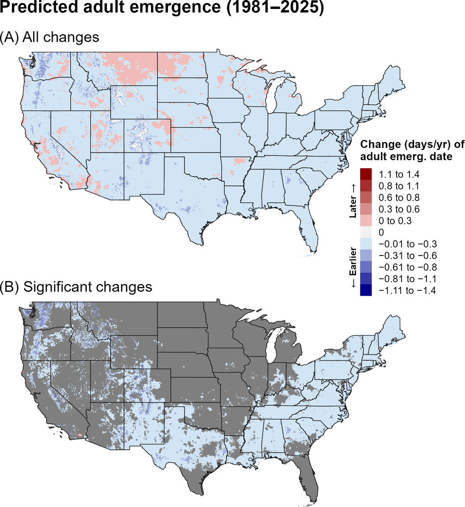

Figure 1: Changes (days/year) in predicted dates of first adult emergence for OAB across the CONUS over the entire 44-year period (1981–2025). Maps show (A) all changes and (B) statistically significant changes (P < 0.1); areas shown in gray are not statistically significant.

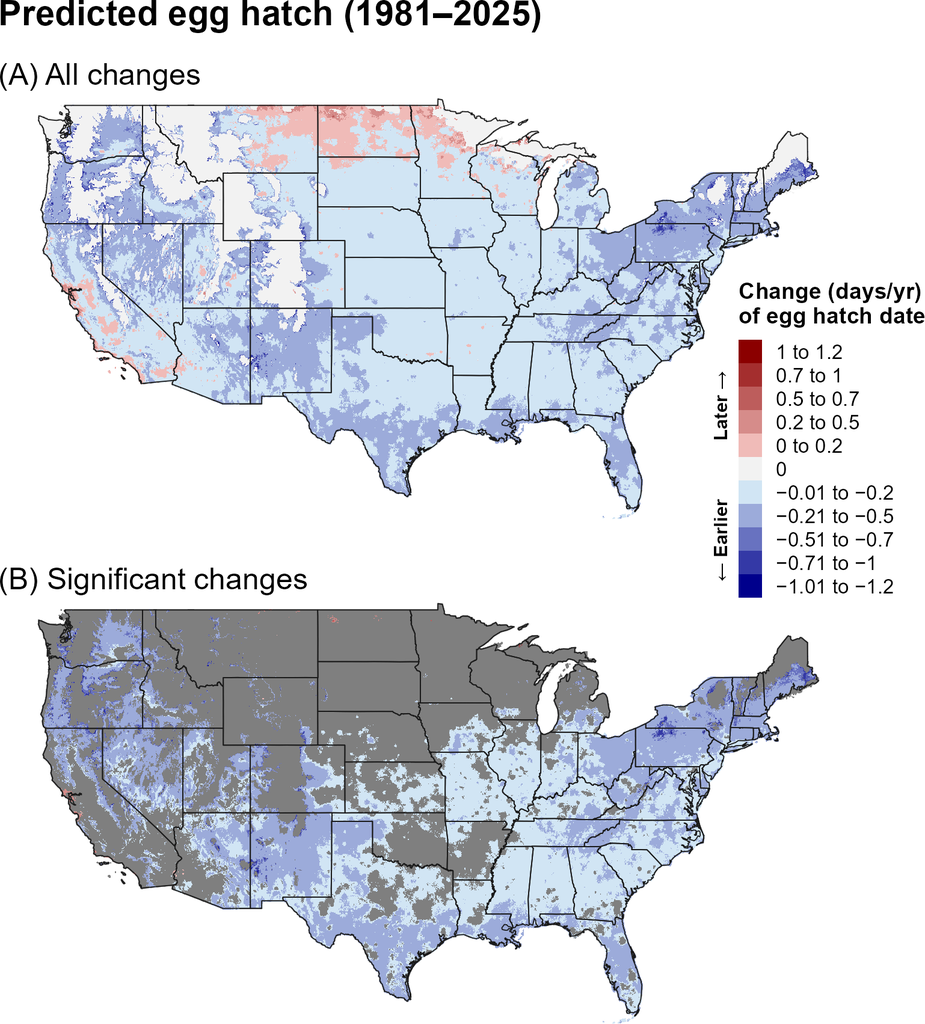

Figure 2: Changes (days/year) in predicted dates of first egg hatch for OAB across the CONUS over the entire 44-year period (1981–2025). Maps show (A) all changes and (B) statistically significant changes (P < 0.1); areas shown in gray are not statistically significant.

#### **Recent period: 2001–2025**

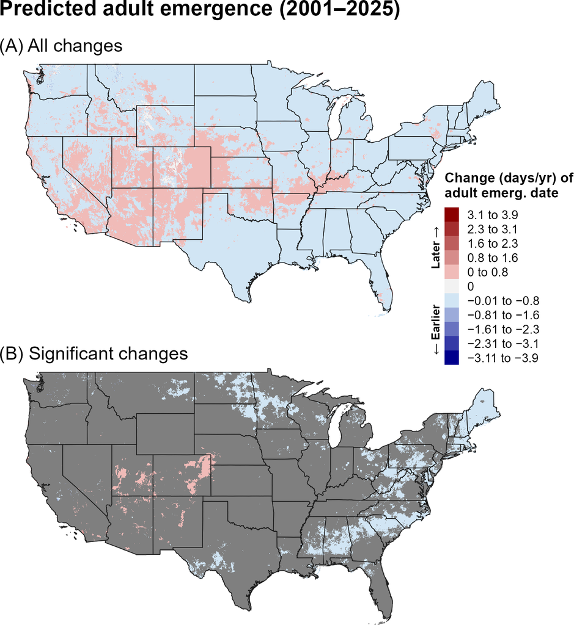

Figure 3: Changes (days/year) in predicted dates of first adult emergence for OAB across the CONUS over the recent 24-year period (2001–2025). Maps show (A) all changes and (B) statistically significant changes (P < 0.1); areas shown in gray are not statistically significant.

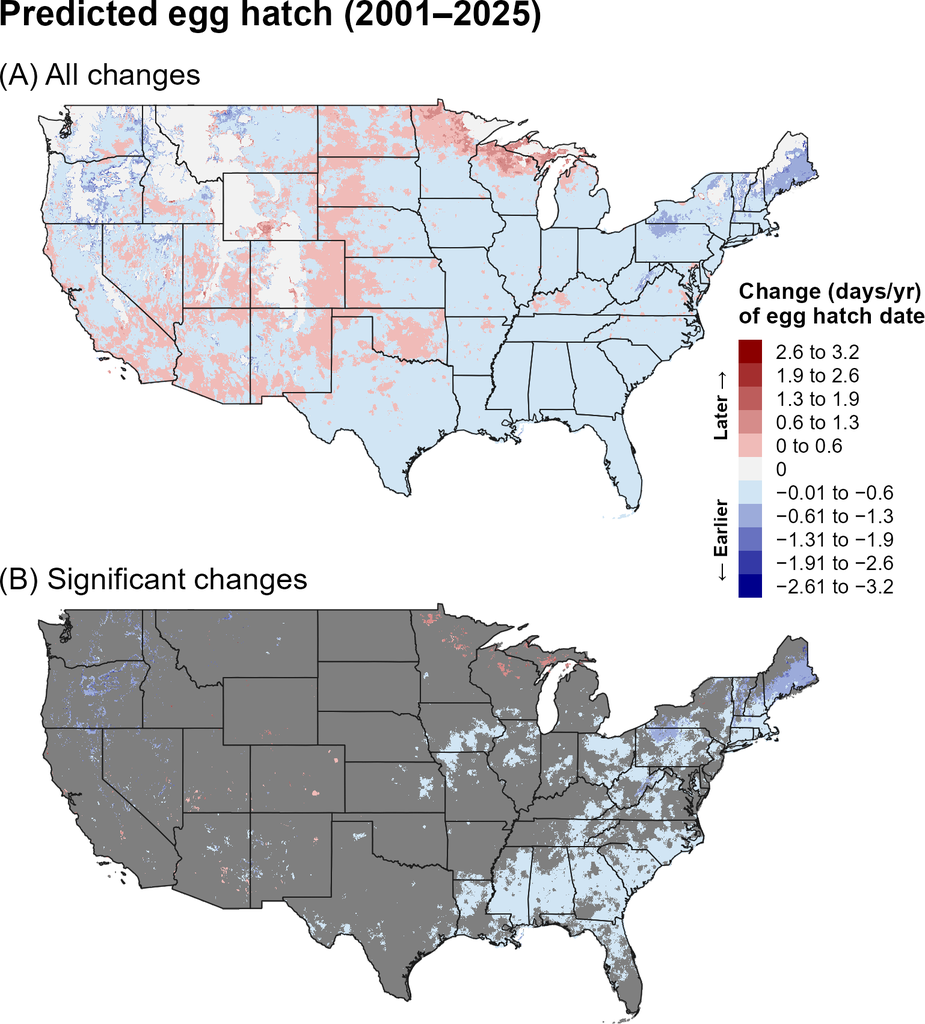

Figure 4: Changes (days/year) in predicted dates of first egg hatch for OAB across the CONUS over the recent 24-year period (2001–2025). Maps show (A) all changes and (B) statistically significant changes (P < 0.1); areas shown in gray are not statistically significant.

### **ii. Climatic suitability**

#### **Entire period: 1981–2025**

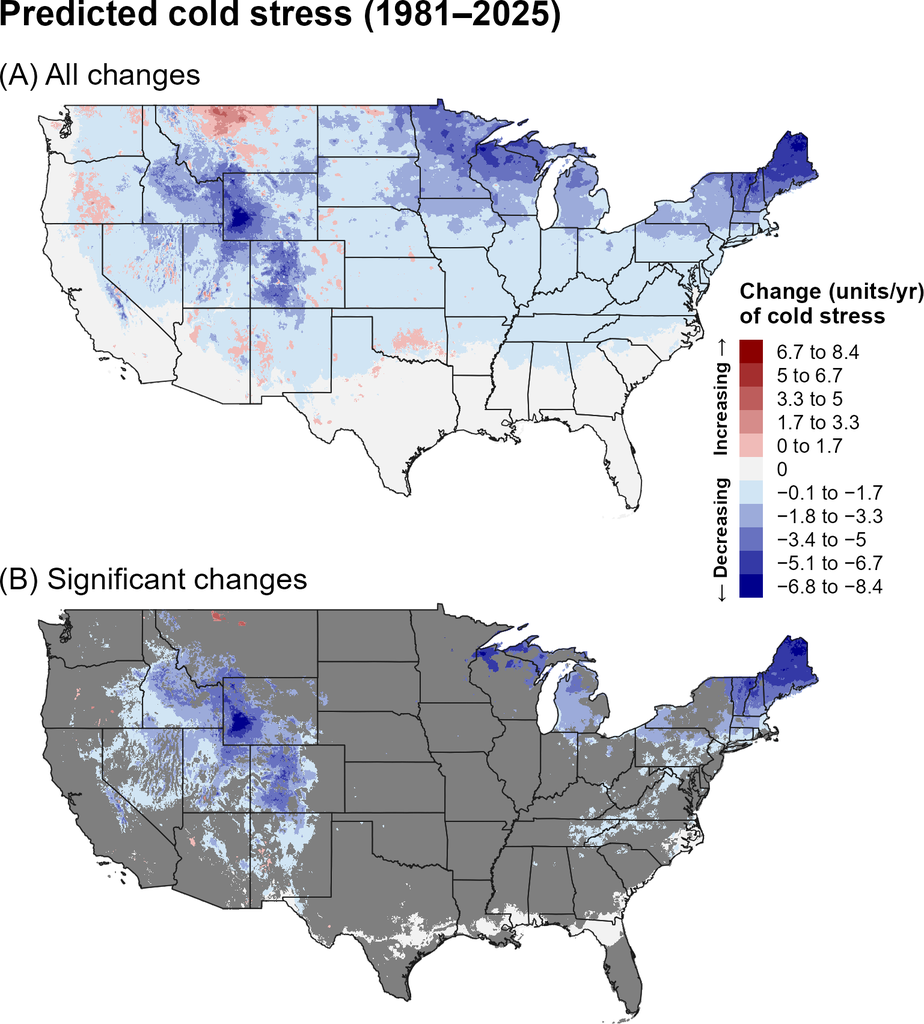

Figure 5: Changes (units/year) in predicted cold stress for OAB across the CONUS over the entire 44-year period (1981–2025). Maps show (A) all changes and (B) statistically significant changes (P < 0.1); areas shown in gray are not statistically significant. Areas shown as 0 in (B) had significant trends but very small changes.

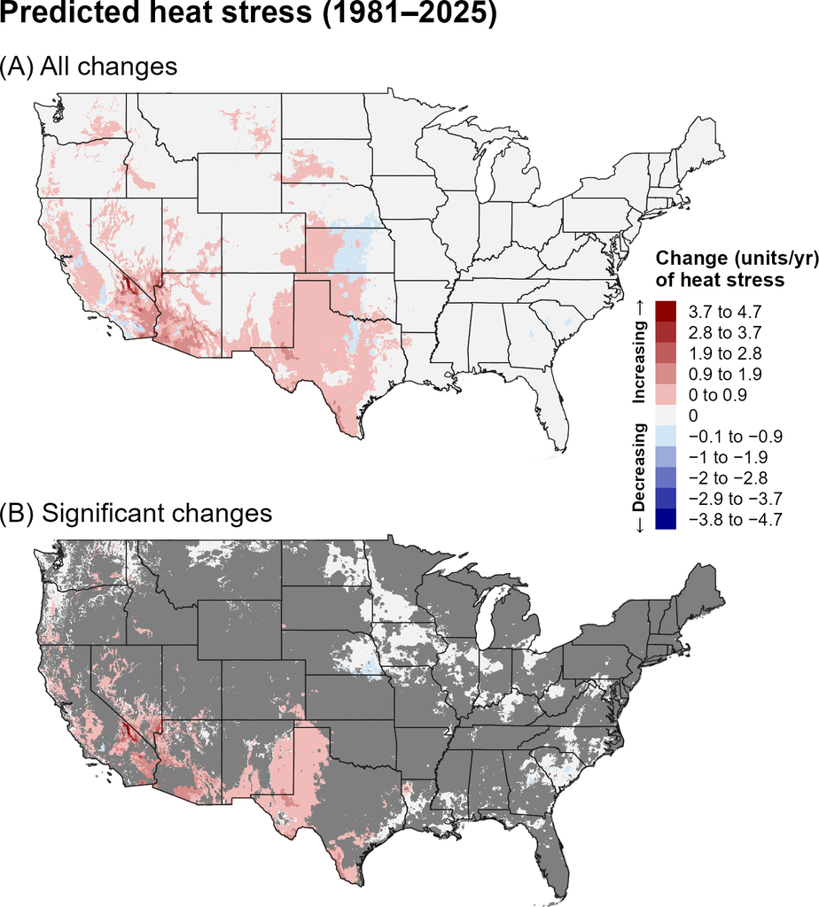

Figure 6: Changes (units/year) in predicted heat stress for OAB across the CONUS over the entire 44-year period (1981–2025). Maps show (A) all changes and (B) statistically significant changes (P < 0.1); areas shown in gray are not statistically significant. Areas shown as 0 in (B) had significant trends but very small changes.

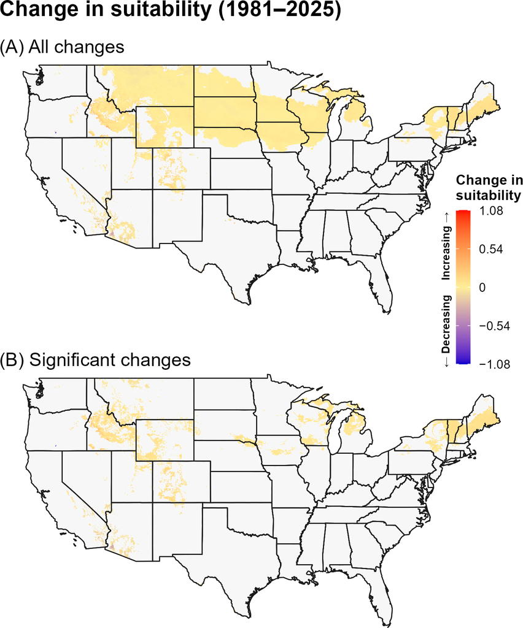

Figure 7: Changes in predicted climatic suitability for OAB across the CONUS over the 44-year period (1981–2025). Suitability is defined as areas not excluded by climate stress. Positive changes (warmer colors) indicate an increased likelihood of establishment, whereas negative changes (cooler colors) indicate a decreased likelihood of establishment.

#### **Recent period: 2001–2025**

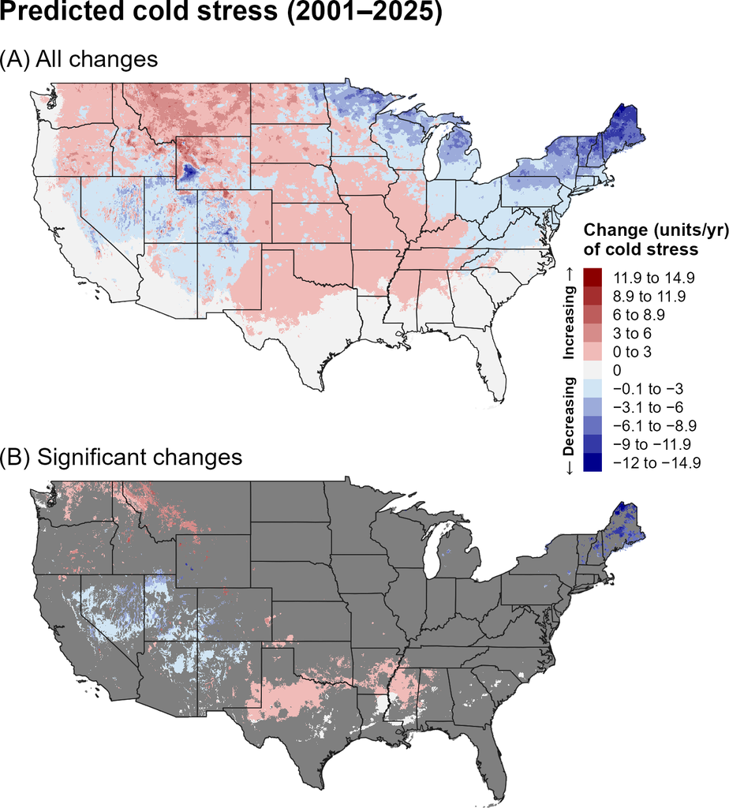

Figure 8: Changes (units/year) in predicted cold stress for OAB across the CONUS over the recent 24-year period (2001–2025). Maps show (A) all changes and (B) statistically significant changes (P < 0.1); areas shown in gray are not statistically significant. Areas shown as 0 in (B) had significant trends but very small changes.

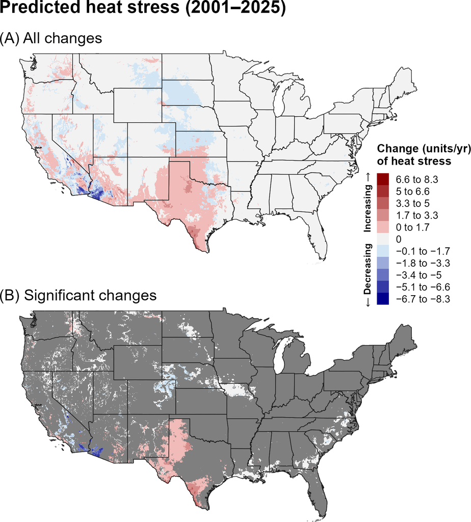

Figure 9: Changes (units/year) in predicted heat stress for OAB across the CONUS over the recent 24-year period (2001–2025). Maps show (A) all changes and (B) statistically significant changes (P < 0.1); areas shown in gray are not statistically significant. Areas shown as 0 in (B) had significant trends but very small changes.

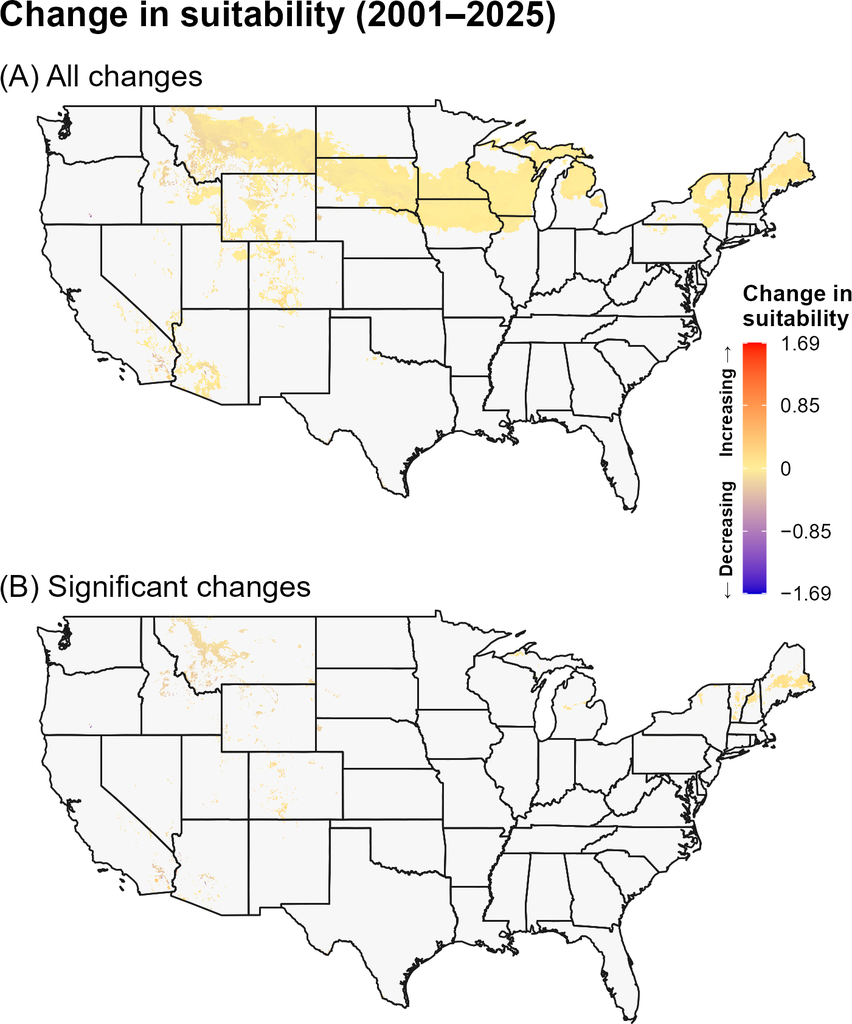

Figure 10: Changes in predicted climatic suitability for OAB across the CONUS over the recent 24-year period (2001–2025). Suitability is defined as areas not excluded by climate stress. Positive changes (warmer colors) indicate an increased likelihood of establishment, whereas negative changes (cooler colors) indicate a decreased likelihood of establishment.

## **10C. Discussion**

Predicted phenology for OAB generally shifted earlier over the full period, particularly across the eastern and central United States. These changes could alter the seasonal timing of adult activity and detection in regions where the pest can establish. The reduction in spatial extent during the recent period suggests that shorter-term climate variability has moderated some of the longer-term phenological signal.

The increase in predicted suitability across portions of the northern United States corresponds with decreasing cold stress over the same period, suggesting that cold conditions have become less limiting in these regions. Recent increases in cold stress across parts of the northern interior were accompanied by fewer significant suitability changes, indicating that the establishment signal is sensitive to the period examined.

The stronger and more spatially extensive trends in predicted phenology and climate stress over the full 44-year period may reflect both the larger sample size, which can reduce noise and improve detection of directional patterns, and differences in the underlying climate trends between the two time periods. In particular, the recent 24-year period may capture climate variability or regional trends that differ from those observed over the longer 44-year period. Thus, differences between the two periods should be interpreted as reflecting both long-term climate trends and shorter-term regional variability.

## **10D. References**

Barker, B. S., and L. Coop. 2020. Oak ambrosia beetle, *Platypus quercivorus*. Phenology/degree-day and climate suitability white paper for USPEST.ORG. Prepared for United States Department of Agriculture (USDA) – Animal and Plant Health Inspection Service (APHIS) – Plant Protection and Quarantine (PPQ). Vs. 1.0 (3/27/2020). Online at: https://uspest.org/CAPS/Platypus_quercivorus_white_paper.pdf (accessed 22 September 2025).

Davis, E. E., S. French, and R. C. Venette. 2005. Mini risk assessment: Ambrosia beetle, *Platypus quercivorus* Murayama [Coleoptera: Platypodidae]. U.S. Department of Agriculture, Animal and Plant Health Inspection Service, Plant Protection and Quarantine, Center for Plant Health Science and Technology, St. Paul, MN. 29 pp.

EPPO. 2020. EPPO Technical Document No. 1081, EPPO Study on the risk of bark and ambrosia beetles associated with imported non-coniferous wood. EPPO, Paris. Online at: https://www.eppo.int/media/uploaded_images/RESOURCES/eppo_publications/TD-1081_EPPO_Study_bark_ambrosia.pdf?utm_source=chatgpt.com (accessed 16 September 2026).

Kamata, N., K. Esaki, K. Kato, Y. Igeta, and K. Wada. 2002. Potential impact of global warming on deciduous oak dieback caused by ambrosia fungus *Raffaelea* sp. carried by ambrosia beetle *Platypus quercivorus* (Coleoptera: Platypodidae) in Japan. Bulletin of Entomological Research 92:119–126.

Kinuura, H. 1995. Life history of *Platypus quercivorus* (Murayama) (Coleoptera: Platypodidae). Pages 373–383 *in* F. P. Hain, W. F. Salom, W. F. Ravlin, T. L. Payne, and K. F. Raffa, editors. Behavior, Population Dynamics and Control of Forest Insects: Proceedings of a Joint IUFRO Working Party Conference, Maui, Hawaii, February 6-11, 1994. Ohio State University, Wooster, OH.

Kinuura, H. 2002. Relative dominance of the mold fungus, Raffaelea sp., in the mycangium and proventriculus in relation to adult stages of the oak platypodid beetle, *Platypus quercivorus* (Coleoptera; Platypodidae). Journal of Forest Research 7:7–12.

Kobayashi, M. 2020. Influence of climate conditions on the flying behavior of *Platypus quercivorus* (Murayama). Applied Forest Science 29:23–31.

Kobayashi, M., and A. Ueda. 2005. Wilt disease of *Fagaceae* trees caused by *Platypus quercivorus* (Murayama) (Coleoptera: Platypodidae) and the associated fungus: Aim is to clarify the damage factor. Journal of the Japanese Forest Society 87:435–450.

Kubono, T., and S. Ito. 2002. *Raffaelea quercivora* sp. nov. associated with mass mortality of Japanese oak, and the ambrosia beetle (*Platypus quercivorus*). Mycoscience 43:255–260.

Nakajima, H. 2019. Region-wide mass mortality of Japanese oak due to ambrosia beetle infestation: Mortality factors and change in oak abundance. Forest Ecology and Management 449:117468.

Takeuchi, Y., A. Tripodi, and K. Montgomery. 2023. SAFARIS: A spatial analytic framework for pest forecast systems. Frontiers in Insect Science 3:1198355.

USDA-APHIS. 2011. New pest response guidelines: Exotic wood-boring and bark beetles. United States Department of Agriculture (USDA) – Animal and Plant Health Inspection Service (APHIS).